# parcing_git

Импорт библиотек

```python
import pandas as pd
import re
import matplotlib.pyplot as plt
import numpy as np
import seaborn as sns
import statsmodels.api as sm
import datetime as dt
import plotly.graph_objects as go
from scipy import stats
import plotly.io as pio
```

```python
pio.renderers.default = 'notebook_connected'
```

```python
plt.style.use('ggplot')
```

```python
from google.colab import drive
drive.mount('/content/drive')
```

```python
data = pd.read_csv(r'/content/drive/MyDrive/animego_parcing.csv')
```

```python
pd.set_option('display.max_colwidth', None)
```

# Описание:

Данные с сайта animego.org за 01.05.2023. Написал парсер на python. Визуализировал в Tableau: Предпочтения пользователей из России(80% пользователей из РФ (данные взяты с www.similarweb.com).

```python
data.head()
```

|  | Unnamed: 0 | Название | Рейтинг | Количество отзывов | Тип | Эпизоды | Статус | Жанр | Первоисточник | Сезон | Выпуск | Студия | Рейтинг MPAA | Возрастные ограничения | Длительность | Снят по манге | Главные герои |
| --- | --- | --- | --- | --- | --- | --- | --- | --- | --- | --- | --- | --- | --- | --- | --- | --- | --- |
| 0 | 0 | Всем возможным тебе, которых я любил | 8,3 | 103 | Фильм | NaN | NaN | Романтика, Фантастика | Новелла | NaN | 7 октября 2022 | NaN | PG-13 | 16+ | 1 ч. 42 мин. | NaN | Коёми ТакасакиКадзунэ Такигава (озвучивает Ай Хасимото) |
| 1 | 1 | Единственному мне, кто тебя любил | 8,7 | 104 | Фильм | NaN | NaN | Романтика, Фантастика | Новелла | NaN | 7 октября 2022 | TMS Entertainment | PG-13 | 16+ | 1 ч. 38 мин. | NaN | Коёми ХидакаСиори Сато (озвучивает Адзю Макита) Коёми ТакасакиКадзунэ Такигава (озвучивает Ай Хасимото) |
| 2 | 2 | Принцесса-шпионка: Укротитель короны | Нет оценок | 0 | Фильм | NaN | NaN | Детектив, Исторический, Экшен | Оригинал | NaN | 11 февраля 2021 | Actas | NC-17 | 18+ | 53 мин. | NaN | Беатрис (озвучивает Акари Кагэяма) Шарлотта (озвучивает Акира Сэкинэ) Дороти (озвучивает Ё Таити) Анж ле Карре (озвучивает Аой Кога) Тисэ Тодо (озвучивает Нодзоми Фуруки) |
| 3 | 3 | О моём перерождении в слизь: Алые узы | 9,0 | 4377 | Фильм | NaN | NaN | Демоны, Комедия, Приключения, Фэнтези, Экшен | Оригинал | NaN | 25 ноября 2022 | 8bit | PG-13 | 16+ | 1 ч. 48 мин. | NaN | Римуру Темпест (озвучивает Михо Окасаки) |
| 4 | 4 | Госпожа Кагуя: в любви как на войне — Первый поцелуй никогда не заканчивается | 9,3 | 1328 | Фильм | NaN | NaN | Драма, Комедия, Романтика | Манга | NaN | 17 декабря 2022 | A-1 Pictures Inc. | PG-13 | 16+ | 1 ч. 36 мин. | Госпожа Кагуя: в любви как на войне | Кагуя Синомия (озвучивает Аой Кога) Миюки Сироганэ (озвучивает Макото Фурукава) |

# Предобработка данных:

Убрать пропуски, удалить ненужные столбцы, привести данные в нужные форматы.

```python
data.info()
```

```
<class 'pandas.core.frame.DataFrame'>
RangeIndex: 2150 entries, 0 to 2149
Data columns (total 17 columns):
 #   Column                  Non-Null Count  Dtype
---  ------                  --------------  -----
 0   Unnamed: 0              2150 non-null   int64
 1   Название                2150 non-null   object
 2   Рейтинг                 2150 non-null   object
 3   Количество отзывов      2150 non-null   int64
 4   Тип                     2150 non-null   object
 5   Эпизоды                 1904 non-null   float64
 6   Статус                  1588 non-null   object
 7   Жанр                    2138 non-null   object
 8   Первоисточник           2106 non-null   object
 9   Сезон                   1375 non-null   object
 10  Выпуск                  2150 non-null   object
 11  Студия                  1973 non-null   object
 12  Рейтинг MPAA            2056 non-null   object
 13  Возрастные ограничения  2150 non-null   object
 14  Длительность            2137 non-null   object
 15  Снят по манге           982 non-null    object
 16  Главные герои           2053 non-null   object
dtypes: float64(1), int64(2), object(14)
memory usage: 285.7+ KB
```

```python
data.isna().mean() * 100
```

```
Unnamed: 0                 0.000000
Название                   0.000000
Рейтинг                    0.000000
Количество отзывов         0.000000
Тип                        0.000000
Эпизоды                   11.441860
Статус                    26.139535
Жанр                       0.558140
Первоисточник              2.046512
Сезон                     36.046512
Выпуск                     0.000000
Студия                     8.232558
Рейтинг MPAA               4.372093
Возрастные ограничения     0.000000
Длительность               0.604651
Снят по манге             54.325581
Главные герои              4.511628
dtype: float64
```

Столбцы и процент пропусков в них. Снят по манге: 54% пропусков, Сезон: 36% пропусков, статус: 26% пропусков, эпизоды: 11%.

## Уберу некоторые столбцы.

С моей точки зрения следующие столбцы не пригодятся. К тому же один из них имеет большой процент пропусков(более 50%)

```python
data = data.drop(['Главные герои','Снят по манге','Unnamed: 0'],axis=1)
```

```python
data.head(1)
```

|  | Название | Рейтинг | Количество отзывов | Тип | Эпизоды | Статус | Жанр | Первоисточник | Сезон | Выпуск | Студия | Рейтинг MPAA | Возрастные ограничения | Длительность |
| --- | --- | --- | --- | --- | --- | --- | --- | --- | --- | --- | --- | --- | --- | --- |
| 0 | Всем возможным тебе, которых я любил | 8,3 | 103 | Фильм | NaN | NaN | Романтика, Фантастика | Новелла | NaN | 7 октября 2022 | NaN | PG-13 | 16+ | 1 ч. 42 мин. |

## Переименую столбцы.

```python
data.columns = (
    ['title','rating','cnt_reviews','type','cnt_episodes','status','genre','original_source',
    'release_season','release','studio','mpaa','age_restrictions','duration',]
)
```

```python
data.info()
```

```
<class 'pandas.core.frame.DataFrame'>
RangeIndex: 2150 entries, 0 to 2149
Data columns (total 14 columns):
 #   Column            Non-Null Count  Dtype
---  ------            --------------  -----
 0   title             2150 non-null   object
 1   rating            2150 non-null   object
 2   cnt_reviews       2150 non-null   int64
 3   type              2150 non-null   object
 4   cnt_episodes      1904 non-null   float64
 5   status            1588 non-null   object
 6   genre             2138 non-null   object
 7   original_source   2106 non-null   object
 8   release_season    1375 non-null   object
 9   release           2150 non-null   object
 10  studio            1973 non-null   object
 11  mpaa              2056 non-null   object
 12  age_restrictions  2150 non-null   object
 13  duration          2137 non-null   object
dtypes: float64(1), int64(1), object(12)
memory usage: 235.3+ KB
```

При сборе данных, я выставлял фильтр о сборе аниме, которые уже вышли. Но в столбце *status* всё равно есть пропуски. Почему-то на сайте не все аниме,которые уже вышли имеют статус *вышел*. Удалю столбец.

```python
data = data.drop('status',axis=1)
```

## Столбец cnt_episodes:

Есть пропуски

```python
data.query('cnt_episodes.isna()').head()
```

|  | title | rating | cnt_reviews | type | cnt_episodes | genre | original_source | release_season | release | studio | mpaa | age_restrictions | duration |
| --- | --- | --- | --- | --- | --- | --- | --- | --- | --- | --- | --- | --- | --- |
| 0 | Всем возможным тебе, которых я любил | 8,3 | 103 | Фильм | NaN | Романтика, Фантастика | Новелла | NaN | 7 октября 2022 | NaN | PG-13 | 16+ | 1 ч. 42 мин. |
| 1 | Единственному мне, кто тебя любил | 8,7 | 104 | Фильм | NaN | Романтика, Фантастика | Новелла | NaN | 7 октября 2022 | TMS Entertainment | PG-13 | 16+ | 1 ч. 38 мин. |
| 2 | Принцесса-шпионка: Укротитель короны | Нет оценок | 0 | Фильм | NaN | Детектив, Исторический, Экшен | Оригинал | NaN | 11 февраля 2021 | Actas | NC-17 | 18+ | 53 мин. |
| 3 | О моём перерождении в слизь: Алые узы | 9,0 | 4377 | Фильм | NaN | Демоны, Комедия, Приключения, Фэнтези, Экшен | Оригинал | NaN | 25 ноября 2022 | 8bit | PG-13 | 16+ | 1 ч. 48 мин. |
| 4 | Госпожа Кагуя: в любви как на войне — Первый поцелуй никогда не заканчивается | 9,3 | 1328 | Фильм | NaN | Драма, Комедия, Романтика | Манга | NaN | 17 декабря 2022 | A-1 Pictures Inc. | PG-13 | 16+ | 1 ч. 36 мин. |

```python
data.query('cnt_episodes.isna()').info()
```

```
<class 'pandas.core.frame.DataFrame'>
Int64Index: 246 entries, 0 to 2149
Data columns (total 13 columns):
 #   Column            Non-Null Count  Dtype
---  ------            --------------  -----
 0   title             246 non-null    object
 1   rating            246 non-null    object
 2   cnt_reviews       246 non-null    int64
 3   type              246 non-null    object
 4   cnt_episodes      0 non-null      float64
 5   genre             246 non-null    object
 6   original_source   242 non-null    object
 7   release_season    0 non-null      object
 8   release           246 non-null    object
 9   studio            237 non-null    object
 10  mpaa              227 non-null    object
 11  age_restrictions  246 non-null    object
 12  duration          242 non-null    object
dtypes: float64(1), int64(1), object(11)
memory usage: 26.9+ KB
```

Во всех строках, где есть пропуск в столбце *cnt_episodes*, также есть пропуск в столбце *release_season*.  
Также в 5 первых строках, где есть пропуск в столбце *cnt_epidodes* столбец *type* == Фильм, проверю, может везде так.

```python
data.query('cnt_episodes.isna()')['type'].value_counts()
```

```
Фильм    243
Спешл      3
Name: type, dtype: int64
```

Да, так и оказалось. Большинство оказалось фильмами. Видимо на сайте количество серий для фильмов не выставляется.

```python
data.query('type =="Фильм"')['cnt_episodes'].value_counts()
```

```
Series([], Name: cnt_episodes, dtype: int64)
```

Заменю пропуски на количество серий = 1.

```python
data['cnt_episodes'] = data['cnt_episodes'].fillna(1)
```

```python
data.info()
```

```
<class 'pandas.core.frame.DataFrame'>
RangeIndex: 2150 entries, 0 to 2149
Data columns (total 13 columns):
 #   Column            Non-Null Count  Dtype
---  ------            --------------  -----
 0   title             2150 non-null   object
 1   rating            2150 non-null   object
 2   cnt_reviews       2150 non-null   int64
 3   type              2150 non-null   object
 4   cnt_episodes      2150 non-null   float64
 5   genre             2138 non-null   object
 6   original_source   2106 non-null   object
 7   release_season    1375 non-null   object
 8   release           2150 non-null   object
 9   studio            1973 non-null   object
 10  mpaa              2056 non-null   object
 11  age_restrictions  2150 non-null   object
 12  duration          2137 non-null   object
dtypes: float64(1), int64(1), object(11)
memory usage: 218.5+ KB
```

## Столбец genre

Пропуски в genre:

```python
data.query('genre.isna()').head(2)
```

|  | title | rating | cnt_reviews | type | cnt_episodes | genre | original_source | release_season | release | studio | mpaa | age_restrictions | duration |
| --- | --- | --- | --- | --- | --- | --- | --- | --- | --- | --- | --- | --- | --- |
| 16 | Путь домохозяина 2 | 9,1 | 1647 | ONA | 5.0 | NaN | Манга | NaN | 1 января 2023 | J.C. Staff | PG-13 | 16+ | 17 мин. ~ серия |
| 43 | Клуб стрельбы из лука: Зона выстрела | 8,4 | 170 | Спешл | 1.0 | NaN | Легкая новвела | NaN | 3 марта 2019 | Kyoto Animation | PG-13 | 16+ | 24 мин. |

```python
data = data.loc[~data['genre'].isna()]
```

```python
data.query('original_source.isna()').head()
```

|  | title | rating | cnt_reviews | type | cnt_episodes | genre | original_source | release_season | release | studio | mpaa | age_restrictions | duration |
| --- | --- | --- | --- | --- | --- | --- | --- | --- | --- | --- | --- | --- | --- |
| 17 | Старшая карта | 8,3 | 1862 | ТВ Сериал | 12.0 | Фэнтези, Экшен | NaN | Зима 2023 | с 9 января 2023 по 27 марта 2023 | Studio Hibari | NC-17 | 18+ | 23 мин. ~ серия |
| 37 | Кайна в великом снежном море | 7,7 | 554 | ТВ Сериал | 11.0 | Фэнтези | NaN | Зима 2023 | с 12 января 2023 по 23 марта 2023 | Polygon Pictures | PG-13 | 16+ | 22 мин. ~ серия |
| 45 | D4DJ: Первый микс 2 | 6,9 | 104 | ТВ Сериал | 12.0 | Музыка | NaN | Зима 2023 | с 13 января 2023 по 31 марта 2023 | SANZIGEN | PG-13 | 16+ | 23 мин. ~ серия |
| 53 | Технороид: Сверхразум | 6,1 | 201 | ТВ Сериал | 12.0 | Детектив, Музыка, Повседневность, Фантастика | NaN | Зима 2023 | с 5 января 2023 по 30 марта 2023 | Dogakobo | PG-13 | 16+ | 24 мин. ~ серия |
| 250 | Летний призрак | 9,2 | 3588 | Фильм | 1.0 | Сверхъестественное | NaN | NaN | 12 ноября 2021 | NaN | PG-13 | 16+ | 39 мин. |

Пропуски в original_source не столь важны, как пропуски в жанрах. Тут оставлю эти строки без изменений.

## Столбцы release, release_season

release_season - сезон года, когда начинают выходить серии аниме: Лето, Осень, Зима, Весна.

release - даты начала и окончания выпуска серий.

Меня интересует только год выхода, поэтому оставлю только один столбец. В столбце release нет пропусков, так что оттуда буду вытаскивать год.

```python
data['release_year'] = data['release'].apply(lambda x: re.search(r'\d\d\d\d',x).group(0))
```

```python
data = data.drop(['release_season','release'],axis=1)
```

```python
data.info()
```

```
<class 'pandas.core.frame.DataFrame'>
Int64Index: 2138 entries, 0 to 2149
Data columns (total 12 columns):
 #   Column            Non-Null Count  Dtype
---  ------            --------------  -----
 0   title             2138 non-null   object
 1   rating            2138 non-null   object
 2   cnt_reviews       2138 non-null   int64
 3   type              2138 non-null   object
 4   cnt_episodes      2138 non-null   float64
 5   genre             2138 non-null   object
 6   original_source   2094 non-null   object
 7   studio            1962 non-null   object
 8   mpaa              2044 non-null   object
 9   age_restrictions  2138 non-null   object
 10  duration          2125 non-null   object
 11  release_year      2138 non-null   object
dtypes: float64(1), int64(1), object(10)
memory usage: 217.1+ KB
```

```python
data.head()
```

|  | title | rating | cnt_reviews | type | cnt_episodes | genre | original_source | studio | mpaa | age_restrictions | duration | release_year |
| --- | --- | --- | --- | --- | --- | --- | --- | --- | --- | --- | --- | --- |
| 0 | Всем возможным тебе, которых я любил | 8,3 | 103 | Фильм | 1.0 | Романтика, Фантастика | Новелла | NaN | PG-13 | 16+ | 1 ч. 42 мин. | 2022 |
| 1 | Единственному мне, кто тебя любил | 8,7 | 104 | Фильм | 1.0 | Романтика, Фантастика | Новелла | TMS Entertainment | PG-13 | 16+ | 1 ч. 38 мин. | 2022 |
| 2 | Принцесса-шпионка: Укротитель короны | Нет оценок | 0 | Фильм | 1.0 | Детектив, Исторический, Экшен | Оригинал | Actas | NC-17 | 18+ | 53 мин. | 2021 |
| 3 | О моём перерождении в слизь: Алые узы | 9,0 | 4377 | Фильм | 1.0 | Демоны, Комедия, Приключения, Фэнтези, Экшен | Оригинал | 8bit | PG-13 | 16+ | 1 ч. 48 мин. | 2022 |
| 4 | Госпожа Кагуя: в любви как на войне — Первый поцелуй никогда не заканчивается | 9,3 | 1328 | Фильм | 1.0 | Драма, Комедия, Романтика | Манга | A-1 Pictures Inc. | PG-13 | 16+ | 1 ч. 36 мин. | 2022 |

```python
data['release_year'] = data['release_year'].astype('int')
```

## Столбец mpaa и age_restrictions

В данных есть два схожих по смыслу столбца: Рейтинг MPAA - принятая в США система оценки содержания фильма. В зависимости от полученной оценки, зрительская аудитория картины может быть ограничена за счёт исключения из неё детей и подростков.

age_restrictions: Возрастные ограничения.

Есть пропуски в столбце mpaa . Можно его восстановить по столбцу 'age_restrictions.'

Оставлю оба столбца, чтобы сравнить выставление рейтингов.

```python
types = data['mpaa'].value_counts().reset_index()

trace = go.Pie(labels=types['index'], values=types['mpaa'],
               pull=[0.1, 0], marker=dict(colors=["#fed049", "#007580"]),
               title="Рейтинг MPAA",
               textinfo='value+percent')
layout = go.Layout(legend=dict(x=0.75, y=0.6))
fig = go.Figure([trace],layout=layout)
fig.show()
```

[interactive chart not shown]

```python
types = data['age_restrictions'].value_counts().reset_index()

trace = go.Pie(labels=types['index'], values=types['age_restrictions'],
               pull=[0.1, 0], marker=dict(colors=["#fed049", "#007580"]),
               title="Рейтинг MPAA",
               textinfo='value+percent')
layout = go.Layout(legend=dict(x=0.75, y=0.6))
fig = go.Figure([trace],layout=layout)
fig.show()
```

[interactive chart not shown]

```python
data['age_restrictions'].value_counts()
```

```
16+    1375
18+     705
12+      48
6+       10
Name: age_restrictions, dtype: int64
```

```python
data['mpaa'].value_counts()
```

```
PG-13    1441
NC-17     585
R           8
G           6
PG          4
Name: mpaa, dtype: int64
```

```python
data.loc[data['age_restrictions'] == '6+','mpaa'] = data.loc[data['age_restrictions'] == '6+','mpaa'].fillna('PG')
data.loc[data['age_restrictions'] == '12+','mpaa'] = data.loc[data['age_restrictions'] == '12+','mpaa'].fillna('PG-13')
data.loc[data['age_restrictions'] == '16+','mpaa'] = data.loc[data['age_restrictions'] == '16+','mpaa'].fillna('R')
data.loc[data['age_restrictions'] == '18+','mpaa'] = data.loc[data['age_restrictions'] == '18+','mpaa'].fillna('NC-17')
```

## Столбец duration

Столбец duration - заменю на продолжительность в минутах.

```python
data.head(1)
```

|  | title | rating | cnt_reviews | type | cnt_episodes | genre | original_source | studio | mpaa | age_restrictions | duration | release_year |
| --- | --- | --- | --- | --- | --- | --- | --- | --- | --- | --- | --- | --- |
| 0 | Всем возможным тебе, которых я любил | 8,3 | 103 | Фильм | 1.0 | Романтика, Фантастика | Новелла | NaN | PG-13 | 16+ | 1 ч. 42 мин. | 2022 |

```python
# Функция для преобразования в минуты

def convert_to_minutes(duration):
    try:
        some_list =  re.findall(r'\d+',str(duration))
        if len(some_list) == 1:
            return int(some_list[0])
        else:
            minutes = int(some_list[0]) * 60 + int(some_list[1])
            return int(minutes)
    except:
        pass
```

```python
data['duration'] = data['duration'].apply(convert_to_minutes)
```

## Столбец rating приведу к типу int, Нет оценок заменю на 0.

```python
data['rating'] = data['rating'].str.replace('Нет оценок','0')
data['rating'] = data['rating'].str.replace(',','.')
```

```python
data['rating'] = pd.to_numeric(data['rating'])
```

```python
data.head()
```

|  | title | rating | cnt_reviews | type | cnt_episodes | genre | original_source | studio | mpaa | age_restrictions | duration | release_year |
| --- | --- | --- | --- | --- | --- | --- | --- | --- | --- | --- | --- | --- |
| 0 | Всем возможным тебе, которых я любил | 8.3 | 103 | Фильм | 1.0 | Романтика, Фантастика | Новелла | NaN | PG-13 | 16+ | 102.0 | 2022 |
| 1 | Единственному мне, кто тебя любил | 8.7 | 104 | Фильм | 1.0 | Романтика, Фантастика | Новелла | TMS Entertainment | PG-13 | 16+ | 98.0 | 2022 |
| 2 | Принцесса-шпионка: Укротитель короны | 0.0 | 0 | Фильм | 1.0 | Детектив, Исторический, Экшен | Оригинал | Actas | NC-17 | 18+ | 53.0 | 2021 |
| 3 | О моём перерождении в слизь: Алые узы | 9.0 | 4377 | Фильм | 1.0 | Демоны, Комедия, Приключения, Фэнтези, Экшен | Оригинал | 8bit | PG-13 | 16+ | 108.0 | 2022 |
| 4 | Госпожа Кагуя: в любви как на войне — Первый поцелуй никогда не заканчивается | 9.3 | 1328 | Фильм | 1.0 | Драма, Комедия, Романтика | Манга | A-1 Pictures Inc. | PG-13 | 16+ | 96.0 | 2022 |

## В каждой строке столбца 'genre' находится список. Поскольку строк в датасете не слишком много, использую метод *explode*.

```python
data.head(1)
```

|  | title | rating | cnt_reviews | type | cnt_episodes | genre | original_source | studio | mpaa | age_restrictions | duration | release_year |
| --- | --- | --- | --- | --- | --- | --- | --- | --- | --- | --- | --- | --- |
| 0 | Всем возможным тебе, которых я любил | 8.3 | 103 | Фильм | 1.0 | Романтика, Фантастика | Новелла | NaN | PG-13 | 16+ | 102.0 | 2022 |

```python
data_genres = data.copy()
data_genres['genre'] = data_genres['genre'].apply(lambda x: x.split(','))
data_genres = data_genres.explode('genre')
data_genres['genre'] = data_genres['genre'].str.replace(' ', '')
```

```python
data_genres['genre'].unique()
```

```
array(['Романтика', 'Фантастика', 'Детектив', 'Исторический', 'Экшен',
       'Демоны', 'Комедия', 'Приключения', 'Фэнтези', 'Драма',
       'Сверхъестественное', 'Сёнэн', 'Безумие', 'Психологическое',
       'Игры', 'Школа', 'Повседневность', 'Сэйнэн', 'Ужасы', 'СёдзёАй',
       'Гарем', 'Полиция', 'Триллер', 'Боевыеискусства', 'Самураи',
       'Спорт', 'Музыка', 'Этти', 'Вампиры', 'Суперсила', 'Сёдзё',
       'Военное', 'Меха', 'Детское', 'Дзёсэй', 'Пародия', 'Космос',
       'Сёнэн-Aй', 'Магия', 'Машины'], dtype=object)
```

```python
data_genres.head()
```

|  | title | rating | cnt_reviews | type | cnt_episodes | genre | original_source | studio | mpaa | age_restrictions | duration | release_year |
| --- | --- | --- | --- | --- | --- | --- | --- | --- | --- | --- | --- | --- |
| 0 | Всем возможным тебе, которых я любил | 8.3 | 103 | Фильм | 1.0 | Романтика | Новелла | NaN | PG-13 | 16+ | 102.0 | 2022 |
| 0 | Всем возможным тебе, которых я любил | 8.3 | 103 | Фильм | 1.0 | Фантастика | Новелла | NaN | PG-13 | 16+ | 102.0 | 2022 |
| 1 | Единственному мне, кто тебя любил | 8.7 | 104 | Фильм | 1.0 | Романтика | Новелла | TMS Entertainment | PG-13 | 16+ | 98.0 | 2022 |
| 1 | Единственному мне, кто тебя любил | 8.7 | 104 | Фильм | 1.0 | Фантастика | Новелла | TMS Entertainment | PG-13 | 16+ | 98.0 | 2022 |
| 2 | Принцесса-шпионка: Укротитель короны | 0.0 | 0 | Фильм | 1.0 | Детектив | Оригинал | Actas | NC-17 | 18+ | 53.0 | 2021 |

# Исследовательский анализ данных.

Что в итоге осталось из изначальных данных:

```python
data.head()
```

|  | title | rating | cnt_reviews | type | cnt_episodes | genre | original_source | studio | mpaa | age_restrictions | duration | release_year |
| --- | --- | --- | --- | --- | --- | --- | --- | --- | --- | --- | --- | --- |
| 0 | Всем возможным тебе, которых я любил | 8.3 | 103 | Фильм | 1.0 | Романтика, Фантастика | Новелла | NaN | PG-13 | 16+ | 102.0 | 2022 |
| 1 | Единственному мне, кто тебя любил | 8.7 | 104 | Фильм | 1.0 | Романтика, Фантастика | Новелла | TMS Entertainment | PG-13 | 16+ | 98.0 | 2022 |
| 2 | Принцесса-шпионка: Укротитель короны | 0.0 | 0 | Фильм | 1.0 | Детектив, Исторический, Экшен | Оригинал | Actas | NC-17 | 18+ | 53.0 | 2021 |
| 3 | О моём перерождении в слизь: Алые узы | 9.0 | 4377 | Фильм | 1.0 | Демоны, Комедия, Приключения, Фэнтези, Экшен | Оригинал | 8bit | PG-13 | 16+ | 108.0 | 2022 |
| 4 | Госпожа Кагуя: в любви как на войне — Первый поцелуй никогда не заканчивается | 9.3 | 1328 | Фильм | 1.0 | Драма, Комедия, Романтика | Манга | A-1 Pictures Inc. | PG-13 | 16+ | 96.0 | 2022 |

```python
data_genres.head()
```

|  | title | rating | cnt_reviews | type | cnt_episodes | genre | original_source | studio | mpaa | age_restrictions | duration | release_year |
| --- | --- | --- | --- | --- | --- | --- | --- | --- | --- | --- | --- | --- |
| 0 | Всем возможным тебе, которых я любил | 8.3 | 103 | Фильм | 1.0 | Романтика | Новелла | NaN | PG-13 | 16+ | 102.0 | 2022 |
| 0 | Всем возможным тебе, которых я любил | 8.3 | 103 | Фильм | 1.0 | Фантастика | Новелла | NaN | PG-13 | 16+ | 102.0 | 2022 |
| 1 | Единственному мне, кто тебя любил | 8.7 | 104 | Фильм | 1.0 | Романтика | Новелла | TMS Entertainment | PG-13 | 16+ | 98.0 | 2022 |
| 1 | Единственному мне, кто тебя любил | 8.7 | 104 | Фильм | 1.0 | Фантастика | Новелла | TMS Entertainment | PG-13 | 16+ | 98.0 | 2022 |
| 2 | Принцесса-шпионка: Укротитель короны | 0.0 | 0 | Фильм | 1.0 | Детектив | Оригинал | Actas | NC-17 | 18+ | 53.0 | 2021 |

## Распределние по типу:

```python
types = data['type'].value_counts().reset_index()

trace = go.Pie(labels=types['index'], values=types['type'],
               pull=[0.1, 0], marker=dict(colors=["#fed049", "#007580"]),
               title="Anime Content Types")
layout = go.Layout(legend=dict(x=0.65, y=0.6))
fig = go.Figure([trace],layout=layout)
fig.show()
```

[interactive chart not shown]

## Возрастные ограничения

```python
types = data['mpaa'].value_counts().reset_index()

trace = go.Pie(labels=types['index'], values=types['mpaa'],
               pull=[0.1, 0], marker=dict(colors=["#fed049", "#007580"]),
               title="Рейтинг MPAA",
               textinfo='value+percent')
layout = go.Layout(legend=dict(x=0.75, y=0.6))
fig = go.Figure([trace],layout=layout)
fig.show()
```

[interactive chart not shown]

```python
types = data['age_restrictions'].value_counts().reset_index()

trace = go.Pie(labels=types['index'], values=types['age_restrictions'],
               pull=[0.1, 0], marker=dict(colors=["#fed049", "#007580"]),
               title="Возрастной рейтинг",
               textinfo='value+percent')
layout = go.Layout(legend=dict(x=0.75, y=0.6))
fig = go.Figure([trace],layout=layout)
fig.show()
```

[interactive chart not shown]

## Время длительности серии.

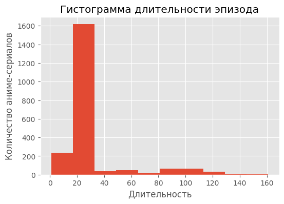

```python
fig = plt.figure(figsize=(6, 4))
ax = fig.add_subplot(111)
data['duration'].hist(ax=ax)
plt.title('Гистограмма длительности эпизода')
plt.ylabel('Количество аниме-сериалов')
plt.xlabel('Длительность')
plt.show()
```

Больше всего аниме имеют длительность эпизода в 20 минут. Это подтверждается распределением по типу аниме. ТВ-Сериалы, в среднем, имеют 20 минут серию.

## Информация про топ 10 аниме по рейтингу.(Самые популярные)

### Сериалы

```python
data['genre'] = data['genre'].str.strip()
```

```python
data.query('type == "ТВ Сериал"').sort_values(['rating','cnt_reviews'],ascending=False).head(10)[['title','rating',"cnt_reviews",'genre','release_year']]
```

|  | title | rating | cnt_reviews | genre | release_year |
| --- | --- | --- | --- | --- | --- |
| 1938 | Охотник х Охотник 2 | 9.6 | 15297 | Приключения, Сёнэн, Супер сила, Фэнтези, Экшен | 2011 |
| 1663 | Крутой учитель Онидзука | 9.6 | 8575 | Драма, Комедия, Повседневность, Сёнэн, Школа | 1999 |
| 369 | Клинок, рассекающий демонов: Квартал красных фонарей | 9.5 | 36179 | Демоны, Исторический, Сверхъестественное, Сёнэн, Фэнтези, Экшен | 2021 |
| 551 | Реинкарнация безработного: История о приключениях в другом мире | 9.5 | 34745 | Драма, Магия, Фэнтези, Этти | 2021 |
| 352 | Реинкарнация безработного: История о приключениях в другом мире. Часть 2 | 9.5 | 30611 | Драма, Фэнтези, Этти | 2021 |
| 1249 | Атака титанов 3. Часть 2 | 9.5 | 18537 | Военное, Детектив, Драма, Сёнэн, Супер сила, Фэнтези, Экшен | 2019 |
| 1573 | Необъятный океан | 9.5 | 15489 | Комедия, Повседневность, Сэйнэн | 2018 |
| 1395 | Гуррен-Лаганн | 9.5 | 11449 | Комедия, Меха, Приключения, Фантастика, Экшен | 2007 |
| 354 | Восемьдесят шесть. Часть 2 | 9.5 | 10960 | Драма, Фантастика, Экшен | 2021 |
| 119 | Блич: Тысячелетняя кровавая война | 9.5 | 9576 | Приключения, Фэнтези, Экшен | 2022 |

### Фильмы

```python
data.query('type == "Фильм"').sort_values(['rating','cnt_reviews'],ascending=False).head(10)[['title','rating',"cnt_reviews",'genre','release_year']]
```

|  | title | rating | cnt_reviews | genre | release_year |
| --- | --- | --- | --- | --- | --- |
| 1513 | Этот глупый свин не понимает мечту девочки-зайки. Фильм | 9.5 | 19092 | Комедия, Романтика, Сверхъестественное, Школа | 2019 |
| 467 | Вайолет Эвергарден. Фильм | 9.5 | 6556 | Драма, Повседневность, Фэнтези | 2020 |
| 963 | Созданный в Бездне: Рассвет глубокой души | 9.5 | 6414 | Детектив, Драма, Приключения, Фантастика, Фэнтези | 2020 |
| 391 | Истребитель демонов: Поезд «Бесконечный» | 9.4 | 22318 | Демоны, Исторический, Сверхъестественное, Сёнэн, Экшен | 2020 |
| 117 | Магическая битва 0. Фильм | 9.4 | 10993 | Фэнтези, Экшен | 2021 |
| 2109 | Твоё имя | 9.3 | 19215 | Драма, Романтика, Сверхъестественное, Школа | 2016 |
| 1949 | Форма голоса | 9.3 | 16763 | Драма, Сёнэн, Школа | 2016 |
| 1267 | Вайолет Эвергарден: Вечность и призрак пера | 9.3 | 3869 | Драма, Повседневность, Фэнтези | 2019 |
| 914 | Созданный в Бездне: Блуждающие сумерки | 9.3 | 1807 | Детектив, Драма, Приключения, Фантастика, Фэнтези | 2019 |
| 4 | Госпожа Кагуя: в любви как на войне — Первый поцелуй никогда не заканчивается | 9.3 | 1328 | Драма, Комедия, Романтика | 2022 |

## Информация про топ 10 аниме по количеству оценок.

### Сериалы

```python
data.query('type == "ТВ Сериал"').sort_values(['cnt_reviews','rating'],ascending=False).head(10)[['title','rating',"cnt_reviews",'genre','release_year']]
```

|  | title | rating | cnt_reviews | genre | release_year |
| --- | --- | --- | --- | --- | --- |
| 1320 | Клинок, рассекающий демонов | 9.4 | 43777 | Демоны, Исторический, Сверхъестественное, Сёнэн, Экшен | 2019 |
| 129 | Человек-бензопила | 9.4 | 41655 | Демоны, Приключения, Сверхъестественное, Сёнэн, Фэнтези, Экшен | 2022 |
| 369 | Клинок, рассекающий демонов: Квартал красных фонарей | 9.5 | 36179 | Демоны, Исторический, Сверхъестественное, Сёнэн, Фэнтези, Экшен | 2021 |
| 603 | Магическая битва | 9.4 | 35082 | Демоны, Сверхъестественное, Сёнэн, Ужасы, Фэнтези, Школа, Экшен | 2020 |
| 551 | Реинкарнация безработного: История о приключениях в другом мире | 9.5 | 34745 | Драма, Магия, Фэнтези, Этти | 2021 |
| 307 | Эта фарфоровая кукла влюбилась | 9.1 | 34325 | Повседневность, Романтика, Сэйнэн, Школа | 2022 |
| 555 | Хоримия | 9.4 | 33970 | Комедия, Повседневность, Романтика, Сёнэн, Школа | 2021 |
| 352 | Реинкарнация безработного: История о приключениях в другом мире. Часть 2 | 9.5 | 30611 | Драма, Фэнтези, Этти | 2021 |
| 232 | Семья шпиона | 9.4 | 28782 | Комедия, Сёнэн, Экшен | 2022 |
| 625 | Атака титанов: Финал | 9.4 | 28362 | Военное, Детектив, Драма, Сёнэн, Супер сила, Фэнтези, Экшен | 2020 |

```python
for_graph = data.query('type == "ТВ Сериал"').sort_values(['cnt_reviews','rating'],ascending=False).head(10)[['title','rating',"cnt_reviews",'genre','release_year']]
```

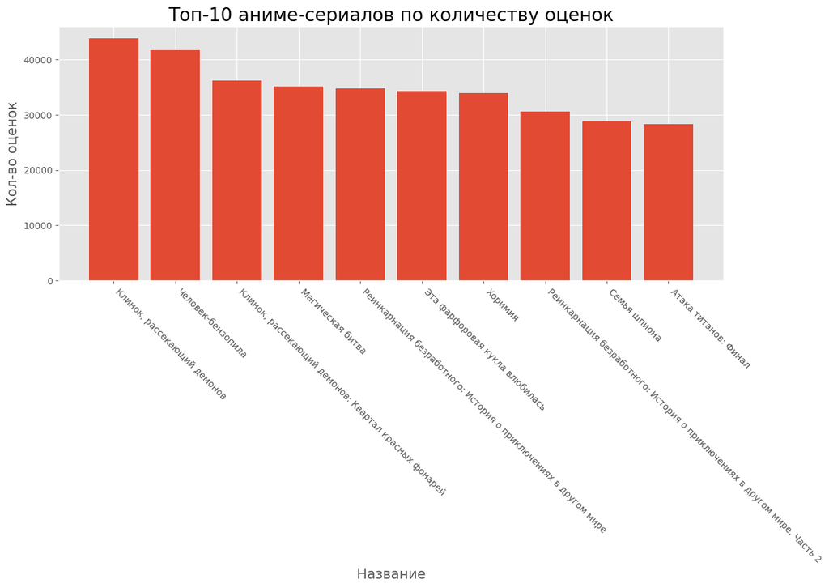

```python
plt.figure(figsize=(13, 5))
plt.bar(x=for_graph['title'],height=for_graph['cnt_reviews'])
plt.xticks(rotation = -45,horizontalalignment ='left')
plt.title('Топ-10 аниме-сериалов по количеству оценок',fontsize=20)
plt.ylabel('Кол-во оценок',fontsize=15)
plt.xlabel('Название',fontsize=15)
plt.show()
```

### Фильмы

```python
data.query('type == "Фильм"').sort_values(['cnt_reviews','rating'],ascending=False).head(10)[['title','rating',"cnt_reviews",'genre','release_year']]
```

|  | title | rating | cnt_reviews | genre | release_year |
| --- | --- | --- | --- | --- | --- |
| 391 | Истребитель демонов: Поезд «Бесконечный» | 9.4 | 22318 | Демоны, Исторический, Сверхъестественное, Сёнэн, Экшен | 2020 |
| 2109 | Твоё имя | 9.3 | 19215 | Драма, Романтика, Сверхъестественное, Школа | 2016 |
| 1513 | Этот глупый свин не понимает мечту девочки-зайки. Фильм | 9.5 | 19092 | Комедия, Романтика, Сверхъестественное, Школа | 2019 |
| 1949 | Форма голоса | 9.3 | 16763 | Драма, Сёнэн, Школа | 2016 |
| 1452 | Я хочу съесть твою поджелудочную | 9.2 | 12659 | Драма | 2018 |
| 117 | Магическая битва 0. Фильм | 9.4 | 10993 | Фэнтези, Экшен | 2021 |
| 1140 | Дитя погоды | 9.2 | 8770 | Драма, Повседневность, Романтика, Фэнтези | 2019 |
| 1414 | В лес, где мерцают светлячки | 9.1 | 8540 | Драма, Романтика, Сверхъестественное, Сёдзё | 2011 |
| 731 | Этот замечательный мир! Багровая легенда | 9.1 | 8474 | Комедия, Магия, Пародия, Приключения, Сверхъестественное, Фэнтези | 2019 |
| 1907 | Мастера Меча Онлайн: Порядковый ранг | 8.8 | 6985 | Игры, Приключения, Романтика, Фэнтези, Экшен | 2017 |

```python
for_graph = (
    data.query('type == "Фильм"')
    .sort_values(['cnt_reviews','rating'],ascending=False)
    .head(10)[['title','rating',"cnt_reviews",'genre','release_year']]
)
```

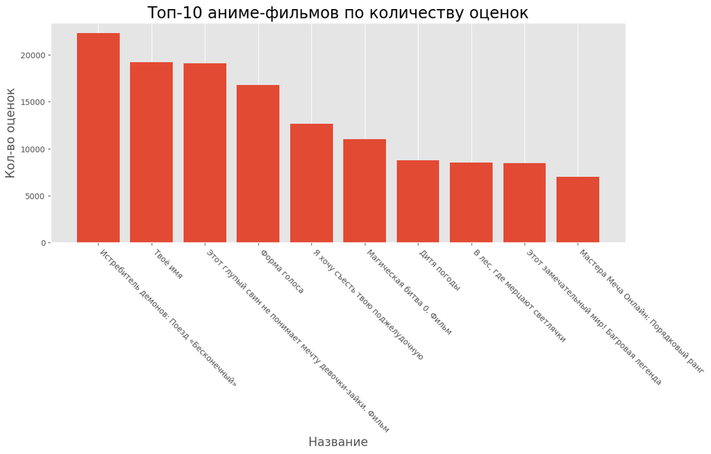

```python
plt.figure(figsize=(13, 5))
plt.bar(x=for_graph['title'],height=for_graph['cnt_reviews'])
plt.xticks(rotation = -45,horizontalalignment ='left')
plt.grid(axis="y")
plt.title('Топ-10 аниме-фильмов по количеству оценок',fontsize=20)
plt.ylabel('Кол-во оценок',fontsize=15)
plt.xlabel('Название',fontsize=15)
plt.show()
```

## Студии

Есть проекты, у которых несколько студий, так что ещё раз использую метод explode.

```python
for_studios = data.copy()
for_studios['studio'] = for_studios['studio'].str.split(',')
for_studios = for_studios.explode('studio')
for_studios['studio'] = for_studios['studio'].fillna('').apply(lambda x: ' '.join([word.strip() for word in x.split()]))
for_studios.head()
```

|  | title | rating | cnt_reviews | type | cnt_episodes | genre | original_source | studio | mpaa | age_restrictions | duration | release_year |
| --- | --- | --- | --- | --- | --- | --- | --- | --- | --- | --- | --- | --- |
| 0 | Всем возможным тебе, которых я любил | 8.3 | 103 | Фильм | 1.0 | Романтика, Фантастика | Новелла |  | PG-13 | 16+ | 102.0 | 2022 |
| 1 | Единственному мне, кто тебя любил | 8.7 | 104 | Фильм | 1.0 | Романтика, Фантастика | Новелла | TMS Entertainment | PG-13 | 16+ | 98.0 | 2022 |
| 2 | Принцесса-шпионка: Укротитель короны | 0.0 | 0 | Фильм | 1.0 | Детектив, Исторический, Экшен | Оригинал | Actas | NC-17 | 18+ | 53.0 | 2021 |
| 3 | О моём перерождении в слизь: Алые узы | 9.0 | 4377 | Фильм | 1.0 | Демоны, Комедия, Приключения, Фэнтези, Экшен | Оригинал | 8bit | PG-13 | 16+ | 108.0 | 2022 |
| 4 | Госпожа Кагуя: в любви как на войне — Первый поцелуй никогда не заканчивается | 9.3 | 1328 | Фильм | 1.0 | Драма, Комедия, Романтика | Манга | A-1 Pictures Inc. | PG-13 | 16+ | 96.0 | 2022 |

```python
studios = (
    for_studios.query('rating != 0 ')
    .groupby('studio')
    .agg({'rating':['mean','median'],'cnt_reviews':'sum','title':'nunique'})
    .reset_index()
)
studios.columns=['studio','mean','median','cnt_reviews','count_title']
studios['mean'] = round(studios['mean'],2)
studios = studios.drop(index=0)
studios.sort_values('cnt_reviews',ascending=False).head(10)
```

|  | studio | mean | median | cnt_reviews | count_title |
| --- | --- | --- | --- | --- | --- |
| 2 | A-1 Pictures Inc. | 8.31 | 8.45 | 320896 | 92 |
| 31 | CloverWorks | 8.68 | 8.90 | 264624 | 26 |
| 26 | Bones | 8.73 | 8.90 | 259777 | 58 |
| 82 | MAPPA | 8.43 | 8.65 | 250933 | 44 |
| 69 | J.C. Staff | 8.21 | 8.40 | 225429 | 90 |
| 83 | Madhouse Studios | 8.59 | 8.80 | 212013 | 73 |
| 142 | Studio Pierrot | 8.15 | 8.15 | 169013 | 38 |
| 106 | Production I.G | 8.19 | 8.50 | 140867 | 68 |
| 177 | ufotable | 8.67 | 8.70 | 131304 | 21 |
| 123 | Silver Link | 7.79 | 7.95 | 130972 | 52 |

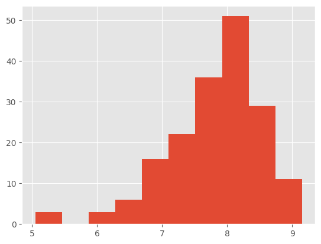

```python
studios['mean'].hist()
plt.show()
```

### Топ-10 по количеству оценок

```python
studios = studios.sort_values('cnt_reviews',ascending=False)
studios.head(10)
```

|  | studio | mean | median | cnt_reviews | count_title |
| --- | --- | --- | --- | --- | --- |
| 2 | A-1 Pictures Inc. | 8.31 | 8.45 | 320896 | 92 |
| 31 | CloverWorks | 8.68 | 8.90 | 264624 | 26 |
| 26 | Bones | 8.73 | 8.90 | 259777 | 58 |
| 82 | MAPPA | 8.43 | 8.65 | 250933 | 44 |
| 69 | J.C. Staff | 8.21 | 8.40 | 225429 | 90 |
| 83 | Madhouse Studios | 8.59 | 8.80 | 212013 | 73 |
| 142 | Studio Pierrot | 8.15 | 8.15 | 169013 | 38 |
| 106 | Production I.G | 8.19 | 8.50 | 140867 | 68 |
| 177 | ufotable | 8.67 | 8.70 | 131304 | 21 |
| 123 | Silver Link | 7.79 | 7.95 | 130972 | 52 |

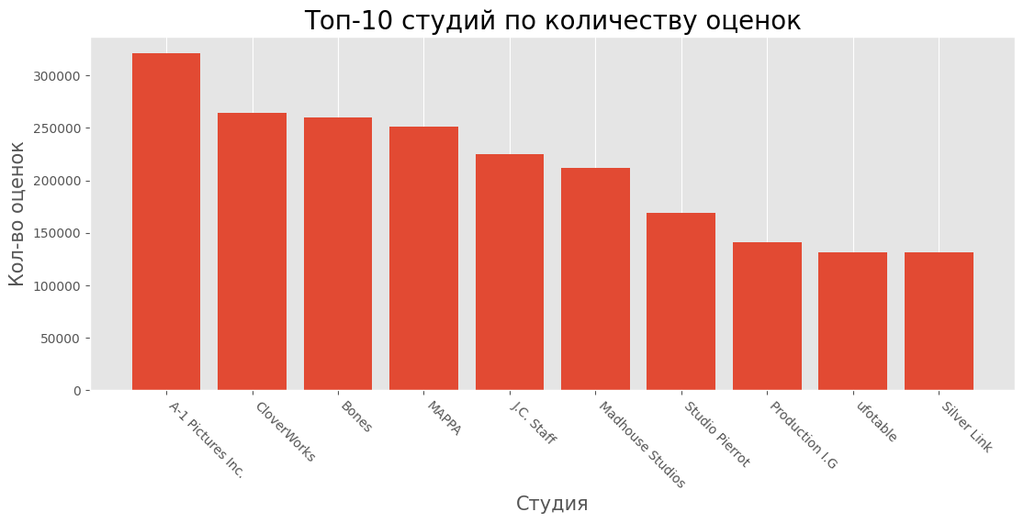

```python
plt.figure(figsize=(13, 5))
plt.bar(x = studios['studio'].head(10), height = studios['cnt_reviews'].head(10))
plt.xticks(rotation = -45,horizontalalignment ='left')
plt.grid(axis="y")
plt.title('Топ-10 студий по количеству оценок',fontsize=20)
plt.ylabel('Кол-во оценок',fontsize=15)
plt.xlabel('Студия',fontsize=15)
plt.show()
```

### Топ-10 по количеству выпущенных тайтлов.

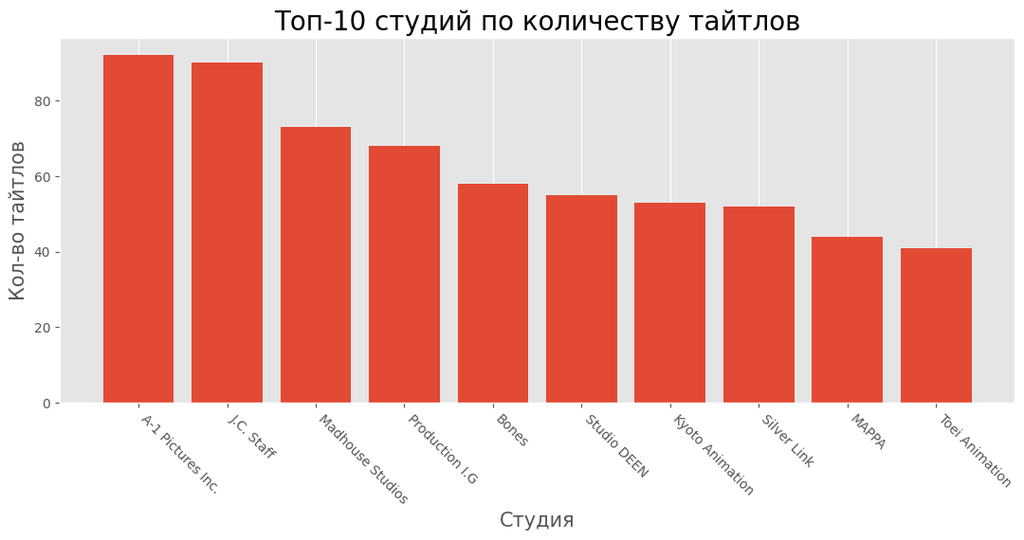

```python
studios = studios.sort_values('count_title',ascending=False)
plt.figure(figsize=(13, 5))
plt.bar(x = studios['studio'].head(10), height = studios['count_title'].head(10))
plt.xticks(rotation = -45,horizontalalignment ='left')
plt.grid(axis="y")
plt.title('Топ-10 студий по количеству тайтлов',fontsize=20)
plt.ylabel('Кол-во тайтлов',fontsize=15)
plt.xlabel('Студия',fontsize=15)
plt.show()
```

### Топ-10 студий по рейтингу.

```python
studios.sort_values('median',ascending=False).head(10)
```

|  | studio | mean | median | cnt_reviews | count_title |
| --- | --- | --- | --- | --- | --- |
| 130 | Studio Bind | 9.10 | 9.50 | 69454 | 3 |
| 44 | Egg Firm | 9.15 | 9.15 | 8647 | 2 |
| 61 | Hal Film Maker | 9.10 | 9.10 | 697 | 1 |
| 50 | G.CMay Animation & Film | 8.75 | 9.00 | 33336 | 10 |
| 53 | Gainax | 8.83 | 9.00 | 38177 | 9 |
| 117 | Seven Arcs | 8.55 | 9.00 | 19482 | 6 |
| 73 | Kinema Citrus | 8.40 | 9.00 | 70865 | 13 |
| 32 | CoMix Wave | 8.75 | 8.95 | 40567 | 4 |
| 166 | Wit Studio | 8.85 | 8.90 | 128480 | 19 |
| 39 | David Production | 8.74 | 8.90 | 88123 | 19 |

```python
studios.sort_values('mean',ascending=False).head(10)
```

|  | studio | mean | median | cnt_reviews | count_title |
| --- | --- | --- | --- | --- | --- |
| 44 | Egg Firm | 9.15 | 9.15 | 8647 | 2 |
| 130 | Studio Bind | 9.10 | 9.50 | 69454 | 3 |
| 61 | Hal Film Maker | 9.10 | 9.10 | 697 | 1 |
| 63 | Hoods Drifters Studio | 8.87 | 8.80 | 5198 | 3 |
| 166 | Wit Studio | 8.85 | 8.90 | 128480 | 19 |
| 53 | Gainax | 8.83 | 9.00 | 38177 | 9 |
| 47 | Fanworks | 8.80 | 8.80 | 2138 | 1 |
| 147 | StudioAnimal Co. | 8.80 | 8.80 | 986 | 1 |
| 32 | CoMix Wave | 8.75 | 8.95 | 40567 | 4 |
| 50 | G.CMay Animation & Film | 8.75 | 9.00 | 33336 | 10 |

```python
studios.query('count_title > 5').sort_values('mean',ascending=False).head(10)
```

|  | studio | mean | median | cnt_reviews | count_title |
| --- | --- | --- | --- | --- | --- |
| 166 | Wit Studio | 8.85 | 8.90 | 128480 | 19 |
| 53 | Gainax | 8.83 | 9.00 | 38177 | 9 |
| 50 | G.CMay Animation & Film | 8.75 | 9.00 | 33336 | 10 |
| 39 | David Production | 8.74 | 8.90 | 88123 | 19 |
| 26 | Bones | 8.73 | 8.90 | 259777 | 58 |
| 31 | CloverWorks | 8.68 | 8.90 | 264624 | 26 |
| 177 | ufotable | 8.67 | 8.70 | 131304 | 21 |
| 104 | Platinum Vision | 8.64 | 8.60 | 11566 | 7 |
| 150 | TMS Entertainment | 8.63 | 8.70 | 121524 | 35 |
| 165 | White Fox | 8.60 | 8.65 | 130873 | 22 |

[figure not shown]

```python
studios = studios.sort_values('mean',ascending=False)
plt.figure(figsize=(13, 5))
plt.bar(x = studios['studio'].head(10), height = studios['mean'].head(10))
plt.xticks(rotation = -45,horizontalalignment ='left')
plt.grid(axis="y")
plt.ylim(8.5,9)
plt.title('Топ-10 студий по среднему рейтингу',fontsize=20)
plt.ylabel('Кол-во тайтлов',fontsize=15)
plt.xlabel('Студия',fontsize=15)
plt.show()
```

## Я иногда замечал достаточно длинные названия аниме. Посмотрим самые длинные из них.(В русском переводе) Немного погогочем.

```python
data['haha'] = data['title'].apply(lambda x: len(x))
# data['haha'] = data['title'].str.len()
```

```python
data.sort_values('haha',ascending=False)[['title','haha']].head(20)
```

|  | title | haha |
| --- | --- | --- |
| 526 | Что, если чрезвычайно развитая ролевая игра с полным погружением вызывает большее привыкание, чем реальность | 108 |
| 381 | Меня выгнали из гильдии героев, потому что я был плохим компаньоном, поэтому я решил неспешно жить в глуши | 106 |
| 1811 | Дракон-горничная госпожи Кобаяси: Валентинки и горячие источники! — Только не ожидайте слишком многого | 102 |
| 179 | Жизнь перерождённого мудреца в другом мире. Получение второй профессии и становление сильнейшим | 95 |
| 100 | Укротитель зверей, изгнанный из команды героя, встретил девочку-кошку из сильнейшей расы | 88 |
| 198 | Вермейл в золотом: Сильнейший маг проходит через магический мир с сильнейшей катастрофой | 88 |
| 38 | Реинкарнация сильнейшего оммёдзи: Эти монстры слишком слабы по сравнению с моим ёкаем | 85 |
| 1268 | Вайолет Эвергарден: День, когда ты поймешь, что я люблю тебя, обязательно наступит | 82 |
| 12 | Дракон-горничная госпожи Кобаяси 2: Японское гостеприимство — Присутствие дракона | 81 |
| 1720 | Звучи! Эуфониум: Добро пожаловать в клуб духового оркестра старшей школы Китауджи | 81 |
| 1003 | Врата Штейна 0: Валентинов кристаллический полиморфизм с горько-сладкой начинкой | 80 |
| 509 | Убивая слизней 300 лет, сама того не заметив, я достигла максимального уровня | 77 |
| 4 | Госпожа Кагуя: в любви как на войне — Первый поцелуй никогда не заканчивается | 77 |
| 266 | Реинкарнация безработного: История о приключениях в другом мире — Спецвыпуск | 76 |
| 89 | Моя жизнь после того, как однажды утром я стал микрофоном в голове манекена | 75 |
| 821 | Некий научный Рейлган S: Все важнейшие открытия делаются во время купания | 73 |
| 619 | Последнее поле брани между тобой и мной, или Святая война сотворения мира | 73 |
| 34 | Сбережение восьмидесяти тысяч золотых монет в другом мире к моей старости | 73 |
| 574 | История о пареньке из деревни, расположенной перед сложнейшим подземельем | 73 |
| 352 | Реинкарнация безработного: История о приключениях в другом мире. Часть 2 | 72 |

Что если не всё так просто и популярность на самом деле зависит от длины названия! Надо срочно это проверить.

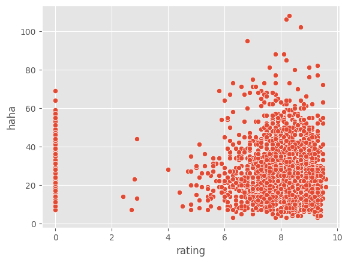

```python
sns.scatterplot(data=data,x='rating',y='haha')
```

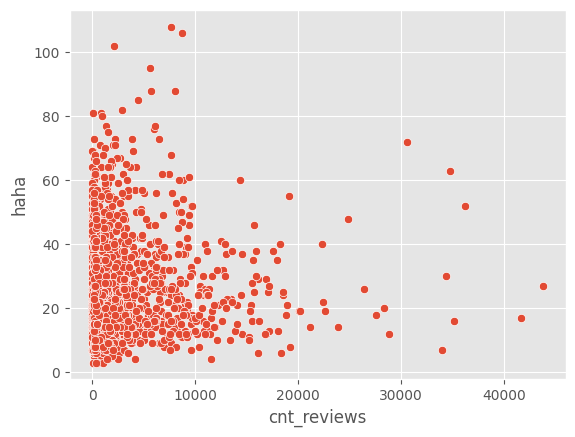

```python
sns.scatterplot(data=data,x='cnt_reviews',y='haha')
```

```python
data.corr()
```

|  | rating | cnt_reviews | cnt_episodes | duration | release_year | haha |
| --- | --- | --- | --- | --- | --- | --- |
| rating | 1.000000 | 0.302155 | 0.081730 | 0.099019 | 0.106188 | -0.020375 |
| cnt_reviews | 0.302155 | 1.000000 | 0.157522 | -0.010193 | 0.155246 | 0.023497 |
| cnt_episodes | 0.081730 | 0.157522 | 1.000000 | -0.172523 | -0.103806 | -0.174222 |
| duration | 0.099019 | -0.010193 | -0.172523 | 1.000000 | -0.103325 | 0.117699 |
| release_year | 0.106188 | 0.155246 | -0.103806 | -0.103325 | 1.000000 | 0.076287 |
| haha | -0.020375 | 0.023497 | -0.174222 | 0.117699 | 0.076287 | 1.000000 |

Так, ни линейной ни какой-либо ещё зависимости не вижу. Можно спать спокойно.

## Жанры

```python
data_genres.head()
```

|  | title | rating | cnt_reviews | type | cnt_episodes | genre | original_source | studio | mpaa | age_restrictions | duration | release_year |
| --- | --- | --- | --- | --- | --- | --- | --- | --- | --- | --- | --- | --- |
| 0 | Всем возможным тебе, которых я любил | 8.3 | 103 | Фильм | 1.0 | Романтика | Новелла | NaN | PG-13 | 16+ | 102.0 | 2022 |
| 0 | Всем возможным тебе, которых я любил | 8.3 | 103 | Фильм | 1.0 | Фантастика | Новелла | NaN | PG-13 | 16+ | 102.0 | 2022 |
| 1 | Единственному мне, кто тебя любил | 8.7 | 104 | Фильм | 1.0 | Романтика | Новелла | TMS Entertainment | PG-13 | 16+ | 98.0 | 2022 |
| 1 | Единственному мне, кто тебя любил | 8.7 | 104 | Фильм | 1.0 | Фантастика | Новелла | TMS Entertainment | PG-13 | 16+ | 98.0 | 2022 |
| 2 | Принцесса-шпионка: Укротитель короны | 0.0 | 0 | Фильм | 1.0 | Детектив | Оригинал | Actas | NC-17 | 18+ | 53.0 | 2021 |

Таблица для жанров.

```python
genres = data_genres.query('rating != 0').groupby('genre').agg({'rating':['mean','median'],'cnt_reviews':['sum','count']}).reset_index()
genres.columns = ['genre','rating_mean','rating_median','cnt_reviews','count']
genres['rating_mean'] = genres['rating_mean'].round(1)
genres
```

|  | genre | rating_mean | rating_median | cnt_reviews | count |
| --- | --- | --- | --- | --- | --- |
| 0 | Безумие | 8.0 | 8.30 | 36064 | 13 |
| 1 | Боевыеискусства | 7.6 | 7.70 | 86560 | 44 |
| 2 | Вампиры | 8.3 | 8.25 | 117321 | 58 |
| 3 | Военное | 8.1 | 8.20 | 196836 | 88 |
| 4 | Гарем | 7.9 | 8.00 | 305381 | 117 |
| 5 | Демоны | 8.4 | 8.60 | 475366 | 102 |
| 6 | Детектив | 8.3 | 8.30 | 596406 | 202 |
| 7 | Детское | 8.0 | 8.10 | 2698 | 5 |
| 8 | Дзёсэй | 8.0 | 8.00 | 15770 | 31 |
| 9 | Драма | 8.4 | 8.50 | 1389687 | 429 |
| 10 | Игры | 8.1 | 8.30 | 261247 | 72 |
| 11 | Исторический | 8.4 | 8.60 | 288511 | 120 |
| 12 | Комедия | 8.1 | 8.30 | 1990858 | 816 |
| 13 | Космос | 8.0 | 8.10 | 16988 | 15 |
| 14 | Магия | 7.9 | 8.10 | 434705 | 169 |
| 15 | Машины | 8.1 | 8.80 | 2755 | 3 |
| 16 | Меха | 7.9 | 8.10 | 143791 | 79 |
| 17 | Музыка | 7.8 | 7.80 | 65036 | 85 |
| 18 | Пародия | 8.1 | 8.30 | 49734 | 30 |
| 19 | Повседневность | 8.2 | 8.30 | 694453 | 365 |
| 20 | Полиция | 8.1 | 8.40 | 59717 | 28 |
| 21 | Приключения | 8.1 | 8.40 | 1275040 | 352 |
| 22 | Психологическое | 8.3 | 8.20 | 535525 | 121 |
| 23 | Романтика | 8.2 | 8.40 | 1274754 | 397 |
| 24 | Самураи | 8.1 | 8.30 | 38648 | 34 |
| 25 | Сверхъестественное | 8.3 | 8.50 | 1374589 | 421 |
| 26 | Спорт | 8.1 | 8.30 | 174236 | 117 |
| 27 | Суперсила | 8.1 | 8.20 | 370881 | 113 |
| 28 | Сэйнэн | 8.2 | 8.40 | 453085 | 196 |
| 29 | Сёдзё | 8.4 | 8.65 | 106438 | 70 |
| 30 | СёдзёАй | 7.8 | 7.90 | 15502 | 16 |
| 31 | Сёнэн | 8.4 | 8.50 | 1620674 | 404 |
| 32 | Сёнэн-Aй | 8.5 | 8.90 | 38320 | 15 |
| 33 | Триллер | 8.5 | 8.50 | 230031 | 53 |
| 34 | Ужасы | 7.9 | 8.00 | 270585 | 87 |
| 35 | Фантастика | 8.0 | 8.20 | 566374 | 282 |
| 36 | Фэнтези | 8.1 | 8.20 | 1978652 | 585 |
| 37 | Школа | 8.1 | 8.30 | 1201547 | 458 |
| 38 | Экшен | 8.1 | 8.20 | 2386307 | 789 |
| 39 | Этти | 7.7 | 7.90 | 437134 | 189 |

## Топ-10 жанров по количеству выпущенных аниме.

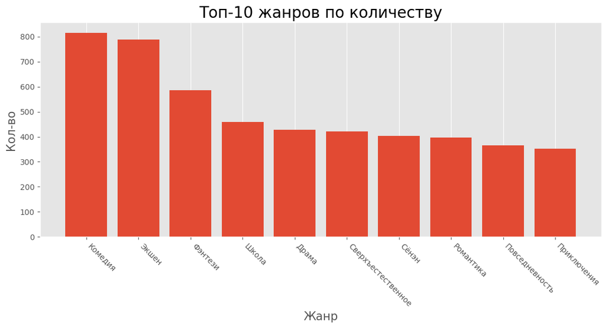

```python
genres_fig = genres.sort_values('count',ascending=False).head(10)
plt.figure(figsize=(13, 5))
plt.bar(x = genres_fig['genre'], height = genres_fig['count'])
plt.xticks(rotation = -45,horizontalalignment ='left')
plt.grid(axis="y")
plt.title('Топ-10 жанров по количеству',fontsize=20)
plt.ylabel('Кол-во',fontsize=15)
plt.xlabel('Жанр',fontsize=15)
plt.show()
```

## Топ-10 по среднему рейтингу

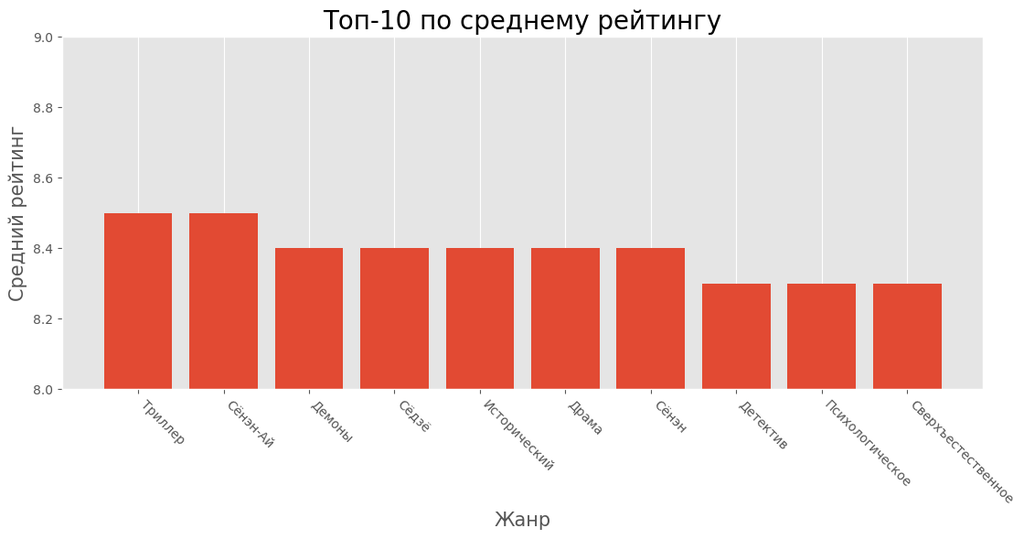

```python
genres_fig = genres.sort_values('rating_mean',ascending=False).head(10)
plt.figure(figsize=(13, 5))
plt.bar(x = genres_fig['genre'], height = genres_fig['rating_mean'])
plt.xticks(rotation = -45,horizontalalignment ='left')
plt.grid(axis="y")
plt.ylim(8,9)
plt.title('Топ-10 по среднему рейтингу',fontsize=20)
plt.ylabel('Средний рейтинг',fontsize=15)
plt.xlabel('Жанр',fontsize=15)
plt.show()
```

Также можно посмотреть в разрезе по годам.

Жанры по годам.

```python
genre_year = data_genres.groupby(['release_year','genre']).agg({'rating':['mean','median'],'cnt_reviews':['sum','count']})
genre_year['rating'] = genre_year['rating'].round(1)
genre_year = genre_year.reset_index()
genre_year.columns = ['year','genre','rating_mean','rating_median','cnt_reviews','count_title']
genre_year = genre_year.sort_values(['year','rating_mean'],ascending=False)
genre_year.head(50)
```

|  | year | genre | rating_mean | rating_median | cnt_reviews | count_title |
| --- | --- | --- | --- | --- | --- | --- |
| 837 | 2023 | Суперсила | 9.2 | 9.2 | 4217 | 1 |
| 839 | 2023 | Сёдзё | 8.7 | 8.7 | 1891 | 1 |
| 825 | 2023 | Демоны | 8.6 | 8.6 | 2220 | 1 |
| 824 | 2023 | Вампиры | 8.4 | 8.4 | 587 | 1 |
| 835 | 2023 | Сверхъестественное | 8.4 | 8.5 | 16853 | 7 |
| 845 | 2023 | Школа | 8.4 | 8.8 | 17207 | 4 |
| 829 | 2023 | Комедия | 8.1 | 8.3 | 68040 | 18 |
| 833 | 2023 | Романтика | 8.1 | 8.6 | 36552 | 10 |
| 834 | 2023 | Самураи | 8.0 | 8.0 | 969 | 1 |
| 838 | 2023 | Сэйнэн | 8.0 | 7.9 | 7558 | 4 |
| 846 | 2023 | Экшен | 7.9 | 7.9 | 48428 | 18 |
| 826 | 2023 | Детектив | 7.8 | 8.0 | 8801 | 5 |
| 832 | 2023 | Приключения | 7.8 | 8.0 | 40104 | 12 |
| 840 | 2023 | СёдзёАй | 7.8 | 7.8 | 2733 | 1 |
| 827 | 2023 | Драма | 7.7 | 7.8 | 7662 | 3 |
| 828 | 2023 | Исторический | 7.7 | 7.7 | 606 | 1 |
| 844 | 2023 | Фэнтези | 7.7 | 7.8 | 70297 | 25 |
| 836 | 2023 | Спорт | 7.6 | 7.6 | 601 | 2 |
| 841 | 2023 | Сёнэн | 7.6 | 7.8 | 11340 | 7 |
| 831 | 2023 | Повседневность | 7.5 | 7.8 | 12435 | 6 |
| 842 | 2023 | Ужасы | 7.3 | 7.3 | 1002 | 1 |
| 843 | 2023 | Фантастика | 7.3 | 7.8 | 3890 | 3 |
| 830 | 2023 | Музыка | 6.5 | 6.5 | 305 | 2 |
| 823 | 2023 | Боевыеискусства | 6.4 | 6.4 | 342 | 2 |
| 847 | 2023 | Этти | 5.7 | 5.7 | 1649 | 1 |
| 815 | 2022 | Сёнэн-Aй | 8.9 | 8.9 | 5405 | 1 |
| 791 | 2022 | Демоны | 8.7 | 8.8 | 55264 | 4 |
| 788 | 2022 | Вампиры | 8.6 | 8.8 | 20174 | 3 |
| 805 | 2022 | Психологическое | 8.6 | 9.0 | 41572 | 5 |
| 792 | 2022 | Детектив | 8.4 | 8.2 | 38223 | 9 |
| 814 | 2022 | Сёнэн | 8.4 | 8.8 | 226030 | 34 |
| 806 | 2022 | Романтика | 8.3 | 8.5 | 167001 | 33 |
| 800 | 2022 | Меха | 8.2 | 8.2 | 3915 | 4 |
| 811 | 2022 | Сэйнэн | 8.2 | 8.6 | 64260 | 13 |
| 820 | 2022 | Школа | 8.2 | 8.4 | 146666 | 26 |
| 795 | 2022 | Драма | 8.1 | 8.0 | 94034 | 23 |
| 799 | 2022 | Космос | 8.1 | 8.1 | 511 | 1 |
| 794 | 2022 | Дзёсэй | 8.0 | 8.0 | 3604 | 2 |
| 798 | 2022 | Комедия | 8.0 | 8.1 | 267642 | 68 |
| 802 | 2022 | Повседневность | 8.0 | 8.1 | 95548 | 35 |
| 808 | 2022 | Сверхъестественное | 8.0 | 8.1 | 122400 | 23 |
| 810 | 2022 | Суперсила | 8.0 | 8.6 | 34193 | 6 |
| 790 | 2022 | Гарем | 7.9 | 7.7 | 43269 | 11 |
| 812 | 2022 | Сёдзё | 7.9 | 8.3 | 4633 | 3 |
| 818 | 2022 | Фантастика | 7.8 | 8.1 | 58307 | 19 |
| 796 | 2022 | Игры | 7.7 | 8.2 | 23816 | 4 |
| 803 | 2022 | Полиция | 7.7 | 7.7 | 1348 | 2 |
| 819 | 2022 | Фэнтези | 7.7 | 7.7 | 335606 | 62 |
| 804 | 2022 | Приключения | 7.6 | 7.7 | 189666 | 36 |
| 821 | 2022 | Экшен | 7.6 | 7.7 | 349242 | 63 |

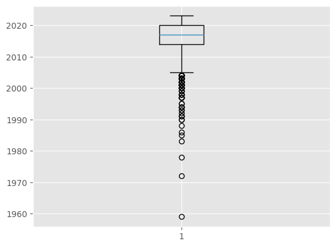

```python
plt.boxplot(data['release_year'])
plt.show()
```

Графики ниже мне были нужны, чтобы я прикинул что и как строить в Tableau.

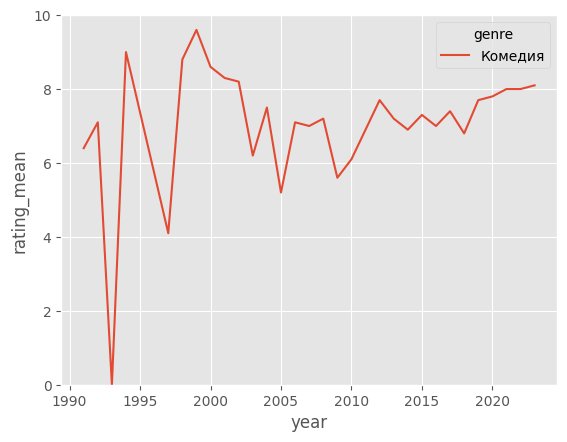

```python
sns.lineplot(data=genre_year.query('genre == "Комедия" and year > 1990'),x='year',y='rating_mean',hue='genre')
plt.ylim(0,10)
plt.show()
```

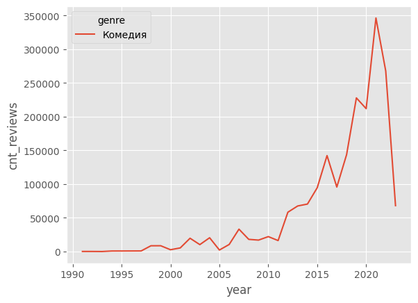

```python
sns.lineplot(data=genre_year.query('genre == "Комедия" and year > 1990'),x='year',y='cnt_reviews',hue='genre')
plt.show()
```

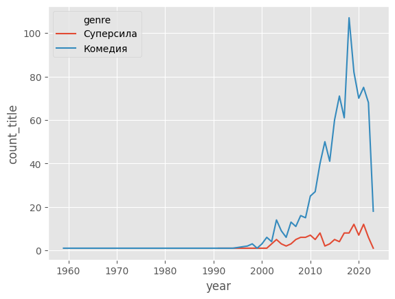

```python
sns.lineplot(data=genre_year.query('genre == "Суперсила" or genre == "Комедия"'),x='year',y='count_title',hue='genre')
plt.show()
```

Тест влияния типа (сериал,фильм и т.д) на рейтинг:  
H0 - средний рейтинг ТВ-Сериалов = средний рейтинг Фильмов  
H1 - средний рейтинг ТВ-Сериалов != средний рейтинг Фильмов  
Приму alpha = 0.05

```python
prop = data.query('rating != 0').groupby('type').agg({'rating':['count','mean','std']}).reset_index()
prop.columns = ['type','count','mean','std']
prop
```

|  | type | count | mean | std |
| --- | --- | --- | --- | --- |
| 0 | ONA | 116 | 7.930172 | 1.002451 |
| 1 | OVA | 146 | 8.109589 | 0.820793 |
| 2 | Спешл | 172 | 7.927326 | 0.762504 |
| 3 | ТВ Сериал | 1278 | 8.049687 | 1.003968 |
| 4 | Фильм | 216 | 8.361111 | 0.739306 |

```python
samp1 = data.query('type == "Фильм" and rating != 0 ')['rating']
samp2 = data.query('type == "ТВ Сериал" and rating != 0')['rating']
samp2
```

```
5       8.9
6       8.6
7       7.5
8       7.9
10      8.6
       ...
2115    9.1
2116    8.9
2119    7.4
2121    9.2
2146    5.3
Name: rating, Length: 1278, dtype: float64
```

```python
t_statistic, p_value = stats.ttest_ind(samp1,samp2, equal_var=False)
t_statistic, p_value
```

```
(5.405553707539504, 1.1712965091696377e-07)
```

p-val < alpha => есть стат.значимые различия.  
Следовательно средний рейтинг Фильмов > средний рейтинг ТВ-Сериалов

# Import

```python
data['genre'] = data['genre'].apply(lambda x: x.replace(" ",""))
data['genre'] = data['genre'].apply(lambda x: x.replace(",",", "))
```

```python
data.to_csv('bigdata.csv')
studios.to_csv('studios.csv')
genres.to_csv('genres.csv')
genre_year.to_csv('genre_year.csv')
```